# Proportional Odds Logistic Regression

2024-09-18

## What is POLR?

- Proportional odds logistic regression (POLR) is an ordinal regression method that can be used for semiparametric modelling of continuous data.
- Introduced by Aitchison and Silvey (1957), named by McCullagh (1980)

## The POLR model

In POLR, the probability of response \(Y\) with k unique values \(y_{j}, j = 1, \dots, k\) exceeding each possible dichotomization of the data, given covariates \(X\), is modelled as:

\[\texttt{logit}(P(Y > y_{j} | X)) = \alpha_{j} + X\beta\]

## The POLR model

- For each cutoff of the response, we have a binomial logistic regression model
- The intercepts differ for each cutoff
- The log odds ratios are the SAME for each cutoff. This is the proportional odds assumption.

## The POLR model

- The POLR model can be viewed as a generalization of the Wilcoxon rank-sum test (Whitehead, 1993)
- POLR score statistic is proportional to Wilcoxon test statistic
- Suggests use for continuous as well as ordinal data

## Fitting the POLR model

`polr` in `MASS` R package

`lrm` and `orm` in `rms` R package

`proc logistic` in SAS

## Data analysis example

- Dataset with expression of AR (by IHC staining) in 69 prostate cancer samples.
- Outcome is semi-quantitative:
  - 0 (no staining)
  - 1 (<10% of neoplastic cells staining)
  - 2 (10%–50% of neoplastic cells staining)
  - 3 (>50% of neoplastic cells staining)
  - Numbers in between the above also used.

## Data analysis example

```r
dat <- read.csv("POLR_example_data.csv")
head(dat, 5)
```

```
##    AR Radiation  PSA
## 1 1.0         0  8.4
## 2 1.0         1  6.7
## 3 0.5         0  4.5
## 4 0.5         1 12.0
## 5 1.0         0  5.5
```

## Data analysis example

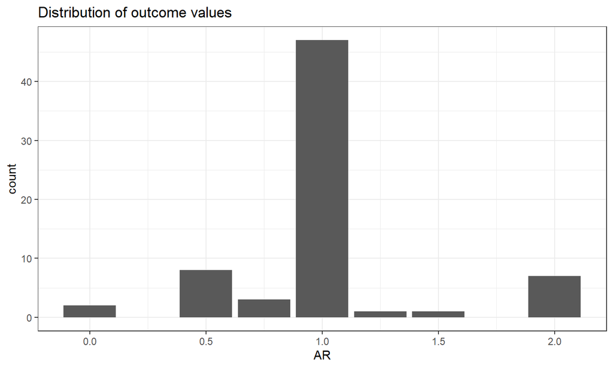

## Data analysis example

- Will will use POLR to compare AR between subjects who did and didn’t get radiation, adjusted for pre-operative PSA.

## Data analysis example

```r
library(MASS)
mod <- polr(factor(AR) ~ Radiation + PSA, data = dat)
```

## Data analysis example

```
## Call:
## polr(formula = factor(AR) ~ Radiation + PSA, data = dat)
##
## Coefficients:
##  Radiation        PSA
## -0.5993227 -0.0218000
##
## Intercepts:
##     0|0.5  0.5|0.75    0.75|1    1|1.25  1.25|1.5     1.5|2
## -3.846186 -2.088987 -1.773449  1.614547  1.748772  1.898832
##
## Residual Deviance: 151.3545
## AIC: 167.3545
```

## Data analysis example

```r
exp(coef(mod))
```

```
## Radiation       PSA
## 0.5491835 0.9784359
```

```r
exp(confint(mod))
```

```
##               2.5 %   97.5 %
## Radiation 0.1572843 1.925334
## PSA       0.9086830 1.049400
```

## Data analysis example

```r
library(car)
Anova(mod)
```

```
## Analysis of Deviance Table (Type II tests)
##
## Response: factor(AR)
##           LR Chisq Df Pr(>Chisq)
## Radiation  0.88387  1     0.3471
## PSA        0.37512  1     0.5402
```

## Data analysis example

- The coefficients from POLR are log odds ratios
- An odds ratio of 0.55 for radiation means that the odds of higher versus lower AR are roughly half as high in subjects who had radiation
- Can be hard for clinicians to understand/interpret

## References

J. Aitchison and S. D. Silvey. The generalization of probit analysis to the case of multiple responses. Biometrika, 44:131–140, 1957. ⋄324

P. McCullagh. Regression models for ordinal data. J Roy Stat Soc B, 42:109– 142, 1980. ⋄313, 324

Harrell, F. E., Jr. (2015). Regression modeling strategies. Springer International Publishing.

## References (cont.)

Whitehead J. Sample size calculations for ordered categorical data. Stat Med. 1993 Dec 30;12(24):2257-71. doi: 10.1002/sim.4780122404. Erratum in: Stat Med 1994 Apr 30;13(8):871. PMID: 8134732.

## Other reading

If You Like the Wilcoxon Test You Must Like the Proportional Odds Model: https://www.fharrell.com/post/wpo/

Violation of Proportional Odds is Not Fatal: https://www.fharrell.com/post/po/